# R Tutorial 4

Adler Torres

2026-Oct-30, 08:42 PM

### Calling packages

```r
library(tidyverse)
library(lessR)
library(readxl)
library(BSDA)
library(dplyr)
library(lsr)
```

### Creating data set object

```r
butterflies <- read_excel("/Users/adlertorres/Documents/Maestria Stuff/R class/Introduction-to-R-2026-Adler-Torres/Lessons/butterflies_pesticides.xlsx")
head(butterflies)
```

```
## # A tibble: 6 × 2
##   Group  `Wing Length`
##   <chr>          <dbl>
## 1 group1          657.
## 2 group1          635.
## 3 group1          675.
## 4 group1          650.
## 5 group1          664.
## 6 group1          634.
```

### Q1. Normality test / Prueba de normalidad (10pts)

```r
shapiro.test(butterflies$`Wing Length`)
```

```
##
##  Shapiro-Wilk normality test
##
## data:  butterflies$`Wing Length`
## W = 0.97134, p-value = 0.06913
```

### Q2. Equality of variances test / Prueba de igualdad de varianzas (10pts)

```r
var.test(`Wing Length` ~ Group, data = butterflies)
```

```
##
##  F test to compare two variances
##
## data:  Wing Length by Group
## F = 0.40274, num df = 39, denom df = 39, p-value = 0.005512
## alternative hypothesis: true ratio of variances is not equal to 1
## 95 percent confidence interval:
##  0.2130078 0.7614644
## sample estimates:
## ratio of variances
##           0.402738
```

Through a variance test, it was found that the variance between groups is not equal, due to the resulting test revealing a p-value less then 0.05.

Q3. Statistical test / Prueba estadística (20pts)

```r
t.test(filter(butterflies, Group == "group1")$`Wing Length`,
       filter(butterflies, Group == "group2")$`Wing Length`,
       alternative = "two.sided",
       mu = 0,
       paired = FALSE,
       var.equal = FALSE)
```

```
##
##  Welch Two Sample t-test
##
## data:  filter(butterflies, Group == "group1")$`Wing Length` and filter(butterflies, Group == "group2")$`Wing Length`
## t = 3.9832, df = 66.029, p-value = 0.0001721
## alternative hypothesis: true difference in means is not equal to 0
## 95 percent confidence interval:
##  19.29467 58.07713
## sample estimates:
## mean of x mean of y
##  632.1756  593.4897
```

```r
cohensD(`Wing Length` ~ Group, data=butterflies)
```

```
## [1] 0.89066
```

### Q4. ggplot (20pts)

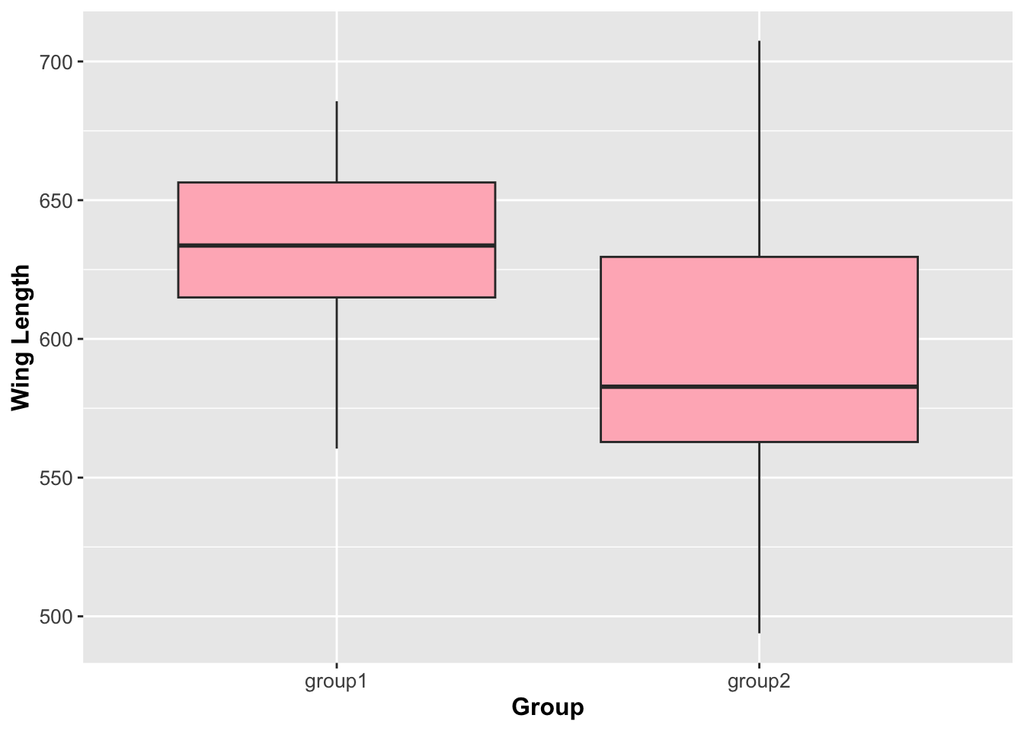

```r
colors <- c('lightpink' )
butterfly_plot <- ggplot(butterflies, aes(x = Group,
                        y = `Wing Length`)) +
  geom_boxplot(fill = colors) +
  labs(x= "Group",
       y= "Wing Length"
       ) +
  theme_grey() +
  theme(legend.position = 'none') +
  theme(
    plot.title = element_text(size = 18, face = "bold", hjust = 0.5),
    axis.title.x = element_text(size = 12, face = "bold"),
    axis.title.y = element_text(size = 12, face = "bold"),
    axis.text.x = element_text(size = 10),
    axis.text.y = element_text(size = 10)
  )
butterfly_plot
```

### Q5. Summary paragraph / Párrafo de resumen (40pts)

We tested to see if there was a significant difference in butterfly development between individuals that were exposed to a pesticide and those who were not. Using a two-tailed independent t-test, we compared 80 individuals, these of which were subdivided into two groups of 40, group 1 being the control while group 2 were exposed to the pesticide. These tests revealed that there does exist a significant and meaningful difference between these groups (t<sub>66</sub> = 3.9832, p < 1.72 x 10<sup>-4</sup>, ES = 0.89). These results indicate that individuals not exposed to pesticide during early stages of development are more likely to reach larger wing sizes during maturity, leading to assume that those exposed to the pesticide will be at a physical disadvantage in the wild.